# Unit Testing in **R**

Anne-Sophie Stelzer, Dominik Cullmann

# Skript

https://fvafrcu.gitlab.io/funktionen_in_r/

https://fvafrcu.gitlab.io/funktionen_in_r/unit_testing.html

# Worum geht es?

- Was soll meine Funktion tun?
- Tut sie es auch?
- Tut sie es auch noch, wenn ich sie verändert/verbessert habe?

# Zwei Funktionen

- Richtige Funktion

```
my_sum <- function(x) {
    value <- 0
    for (x_i in x) {
        value <- value + x_i
    }
    return(value)
}
```

- Falsche Funktion

```
not_my_sum <- function(x) {
    value <- 0
    for (x_i in x) {
        value <- value - x_i
    }
    return(value)
}
```

# Erwartungen

Die kleinste Testeinheit ist immer ein Vergleich.

In base **R**:

```
my_sum(c(2, 7)) == 9
```

```
## [1] TRUE
```

```
# better use identical(), see ?Comparison
identical(not_my_sum(c(2, 7)), 9)
```

```
## [1] FALSE
```

# Pakete

- Wozu
  - Formalisieren
  - Berichten
- Pakete
  - RUnit gibt es schon seit 2004, es ist sehr formal und hat wenige Abhängigkeiten (daher bevorzuge ich es beim Testen von Paketen).
  - testthat finde ich interaktiv einfacher anzuwenden.

# Wieder Erwartungen

RUnit

```
RUnit::checkIdentical(not_my_sum(c(2, 7)), 9)
```

```
## Error in RUnit::checkIdentical(not_my_sum(c(2, 7)), 9): FALSE
##
```

testthat

```
testthat::expect_identical(not_my_sum(c(2, 7)), 9)
```

```
## not_my_sum(c(2, 7)) not identical to 9.
## 1/1 mismatches
## [1] -9 - 9 == -18
```

# Tests

Zusammenfassung mehrer Erwartungen (gewöhnlich für eine Funktion).

Strukturierte Berichte bei mehreren Funktionen (z.B. in Paketen).

# Funktionen testen — testthat

```
testthat::context("My first test.")
testthat::test_that("Simple test on summation.", {
                        testthat::expect_identical(not_my_sum(c(2, 7)), 9,
                                                   info = "Not my sum.")
                        testthat::expect_identical(my_sum(c(2, 7)), 9,
                                                   info = "My sum.")
})
```

```
## Error: Test failed: 'Simple test on summation.'
## * not_my_sum(c(2, 7)) not identical to 9.
## 1/1 mismatches
## [1] -9 - 9 == -18
## Not my sum.
```

# Funktionen testen — RUnit

```
test_sum <- function() {
    RUnit::checkIdentical(not_my_sum(c(2, 7)), 9, msg = "Not my sum")
    RUnit::checkIdentical(my_sum(c(2, 7)), 9, msg = "My sum")
}
test_sum()
```

```
## Error in RUnit::checkIdentical(not_my_sum(c(2, 7)), 9, msg = "Not my sum"): FALSE
##  Not my sum
```

# Testdateien — testthat

```
testthat::test_file(file.path("src", "test_my_sum.R"))
```

```
## ✔ | OK F W S | Context
##
⠏ |  0       | My first test.
⠋ |  0 1     | My first test.
⠙ |  1 1     | My first test.
✖ |  1 1     | My first test.
## ───────────────────────────────────────────────────────────────────────────
## test_my_sum.R:3: failure: Simple test on summation.
## not_my_sum(c(2, 7)) not identical to 9.
## 1/1 mismatches
## [1] -9 - 9 == -18
## Not my sum.
## ───────────────────────────────────────────────────────────────────────────
##
## ══ Results ════════════════════════════════════════════════════════════════
## OK:       1
## Failed:   1
## Warnings: 0
## Skipped:  0
```

# Testdateien — RUnit

```
test_file <- normalizePath(file.path("src", "runit_my_sum.R"))
runit <- RUnit::runTestFile(test_file)
```

```
##
##
## Executing test function test_sum  ... Timing stopped at: 0 0 0.001
##  done successfully.
```

# Testdateien — RUnit II

```
RUnit::printTextProtocol(runit)
```

```
## RUNIT TEST PROTOCOL -- Fri Jul 20 08:33:58 2018
## Number of test functions: 1
## Number of errors: 0
## Number of failures: 1
##
##
## 1 Test Suite :
## runit_my_sum - 1 test function, 0 errors, 1 failure
## FAILURE in test_sum: Error in RUnit::checkIdentical(not_my_sum(c(2, 7)), 9) : FALSE
##
##
##
##
## Details
## Test Suite: runit_my_sum
## Test function regexp: ^test.+
## Test file regexp: ^runit_my_sum.R$
## Involved directory:
## /home/qwer/git/cyclops/fvafrcu/funktionen_in_r/src
## ---------------------------
## Test file: /home/qwer/git/cyclops/fvafrcu/funktionen_in_r/src/runit_my_sum.R
## test_sum: FAILURE !! (check number 1)
## Error in RUnit::checkIdentical(not_my_sum(c(2, 7)), 9) : FALSE
##
```

# Code Coverage

- [Überdeckung](https://en.wikipedia.org/wiki/Code_coverage)
- Paket covr  
  (Ich glaube: [*branch coverage*](https://en.wikipedia.org/wiki/Code_coverage#Coverage_criteria))
- Prinzipiell: Hohe Überdeckung ist gut.

# Code Coverage — Funktionen und Tests in Dateien

src/my_sum_assertion.R

```
my_sum <- function(x) {
    assertthat::assert_that(is.numeric(x))
    value <- 0
    for (x_i in x) {
        value <- value + x_i
    }
    return(value)
}
```

src/test_my_sum_assertion.R

```
testthat::context("Tests for summation with argument assertion.")
testthat::test_that("Testing summation", {
                    testthat::expect_identical(my_sum(c(2, 7)), 9)
                    testthat::expect_error(my_sum(c("2" + "7")))
})
```

# Code Coverage — Dateien

```
cov <- covr::file_coverage(file.path("src", "my_sum_assertion.R"),
                           file.path("src", "test_my_sum_assertion.R"))
print(cov)
```

```
## Coverage: 100.00%
```

```
## src/my_sum_assertion.R: 100.00%
```

# Code Coverage — Ungetesteter Code

src/my_sum_coverage.R

```
my_sum <- function(x) {
    assertthat::assert_that(is.numeric(x))
    if (! is.numeric(x)) message("You'll never get here!")
    value <- 0
    for (x_i in x) {
        value <- value + x_i
    }
    return(value)
}
```

# Code Coverage — Analyse

```
cov <- covr::file_coverage(file.path("src", "my_sum_coverage.R"),
                           file.path("src", "test_my_sum_assertion.R"))
print(cov)
```

```
## Coverage: 83.33%
```

```
## src/my_sum_coverage.R: 83.33%
```

```
print(covr::zero_coverage(cov))
```

```
##                filename functions line value
## 2 src/my_sum_coverage.R    my_sum    3     0
```

# Nebenwirkungen statt Rückgabewerte testen

Fehlerhafte Löschfunktion (vergleiche https://fvafrcu.gitlab.io/funktionen_in_r/#_arbeiten_mit_g%C3%BCltigkeitsbereichen):

src/wipe_clean_broken.R

```
wipe_clean <- function(environment = parent.frame()) {
    objects <- ls(name = environment, all.names = TRUE)
    # FIXME: rm() by default removes objects from
    # the current frame, which is this function, not the parent frame!
    rm(list = objects)
    return(invisible(objects))
}
```

Testdatei:

src/test_wipe_clean_broken.R

```
testthat::test_that("Test return value.", {
                    a <- 3
                    testthat::expect_identical(wipe_clean(),
                                               c("a"))}
                    )
```

# Code Coverage — Analyse Nebenwirkungen

```
cov <- covr::file_coverage(file.path("src", "wipe_clean_broken.R"),
                           file.path("src", "test_wipe_clean_broken.R"))
print(cov)
```

```
## Coverage: 100.00%
```

```
## src/wipe_clean_broken.R: 100.00%
```

Alles gut?  
Nein, die Funktion ist kaputt und die Testdatei, die dies zeigt müsste auf die Nebenwirkung testen!

# Code Coverage — Test der Nebenwirkungen

src/test_wipe_clean.R

```
testthat::test_that("Test return value and side effects.", {
                    a <- 3
                    testthat::expect_identical(wipe_clean(), c("a"))
                    testthat::expect_identical(ls(), character(0))}
                    )
```

```
covr::file_coverage(file.path("src", "wipe_clean_broken.R"),
                    file.path("src", "test_wipe_clean.R"))
```

```
## Error: Test failed: 'Test return value and side effects.'
## * ls() not identical to character(0).
## Lengths differ: 1 is not 0
```

# Was soll die ganze Testerei?

*Ich teste fast alle meine Funktion nach genau dem Ablauf in diesem Beispiel spätestens, wenn ich sie in ein Paket verpacke.*

# [Goldener Schnitt](https://de.wikipedia.org/wiki/Goldener_Schnitt)

src/golden_ratio.R

```
golden_ratio  <- function() {
    phi <- (1 + sqrt(5)) / 2
    return(phi)
}
```

# [Goldener Schnitt](https://de.wikipedia.org/wiki/Goldener_Schnitt) — Trivialer Test

src/test_golden_ratio.R

```
testthat::test_that("Test on Golden Ratio", {
                        expectation <- (1 + sqrt(5)) / 2
                        result <- golden_ratio()
                        testthat::expect_identical(result, expectation)
})
```

```
covr::file_coverage(file.path("src", "golden_ratio.R"),
                    file.path("src", "test_golden_ratio.R"))
```

```
## Coverage: 100.00%
```

```
## src/golden_ratio.R: 100.00%
```

# [Goldenes Rechteck](https://de.wikipedia.org/wiki/Goldener_Schnitt#Goldenes_Rechteck_und_Goldenes_Dreieck)

src/golden_rectangle.R

```
golden_rectangle  <- function(b) {
    a <- b * golden_ratio()
    return(c("a" = a, "b" = b))
}
```

# [Goldenes Rechteck](https://de.wikipedia.org/wiki/Goldener_Schnitt#Goldenes_Rechteck_und_Goldenes_Dreieck) — Test

src/test_golden_rectangle.R

```
testthat::test_that("Test on golden rectangle", {
                        b <- 2
                        expectation <- c(a = b * golden_ratio(), b = b)
                        result <- golden_rectangle(b)
                        testthat::expect_identical(result, expectation)
})
```

```
covr::file_coverage(file.path("src", c("golden_ratio.R", "golden_rectangle.R")),
                    file.path("src", "test_golden_rectangle.R"))
```

```
## Coverage: 100.00%
```

```
## src/golden_ratio.R: 100.00%
```

```
## src/golden_rectangle.R: 100.00%
```

# Anwendung

```
source(file.path("src", "golden_ratio.R"))
width <- 2
png("p1.png", units = "cm", res = 200, width = width, height = golden_rectangle(width)[["a"]])
par(mar=c(1, 1, 1, 1))
plot(cars)
dev.off()
```

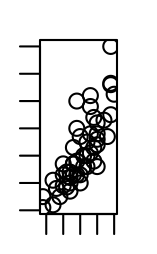

Figure 1. Oh, wie schön!

# Querformat

src/golden_rectangle.R

```
golden_rectangle  <- function(value, landscape = TRUE) {
    phi <- golden_ratio()
    if (isTRUE(landscape)) {
        a  <- value
        b <- a / phi
    } else {
        b <- value
        a <- b * phi
    }
    return(c("a" = a, "b" = b))
}
```

# Anwendung

```
width <- 4
png("p2.png", units = "cm", res = 200, width = width, height = golden_rectangle(width)[["b"]])
par(mar=c(1, 1, 1, 1))
plot(cars)
dev.off()
```

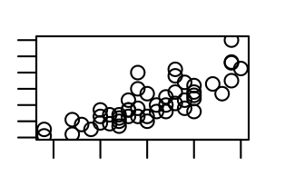

Figure 2. Auch sehr schön!

# Herzlichen Glückwunsch!

```
covr::file_coverage(file.path("src", "golden_rectangle.R"),
                    file.path("src", "test_golden_rectangle.R"))
```

```
## Error: Test failed: 'Test on golden rectangle'
## * `result` not identical to `expectation`.
## 2/2 mismatches (average diff: 1)
## [1] 2.00 - 3.24 == -1.236
## [2] 1.24 - 2.00 == -0.764
```

Was bedeutet das? Du hast die Schnittstelle zerschossen und musst entweder

- **alle** Aufrufe der Funktion, die Du vor der Veränderung ihrer Schnittstelle progammiert hast, anpassen (indem Du `, landscape = FALSE` einfügst) oder
- die Funktion so ändern, dass die Schnittstelle stabil bleibt (und der Test weiterhin funktioniert).

# Korrektur

src/golden_rectangle.R

```
golden_rectangle  <- function(value, landscape = FALSE) {
    phi <- golden_ratio()
    if (isTRUE(landscape)) {
        a  <- value
        b <- a / phi
    } else {
        b <- value
        a <- b * phi
    }
    return(c("a" = a, "b" = b))
}
```

Querformat erstellen: `golden_rectangle(width, landscape = TRUE)`

# Coverage der Korrektur

```
cov <- covr::file_coverage(file.path("src", "golden_rectangle.R"),
                    file.path("src", "test_golden_rectangle.R"))
print(cov)
```

```
## Coverage: 71.43%
```

```
## src/golden_rectangle.R: 71.43%
```

```
print(covr::zero_coverage(cov))
```

```
##                 filename        functions line value
## 3 src/golden_rectangle.R golden_rectangle    4     0
## 4 src/golden_rectangle.R golden_rectangle    5     0
```

# Erweiterung des Tests:

src/test_golden_rectangle.R

```
testthat::test_that("Test on golden rectangle", {
                        value <- 2
                        expectation <- c(a = value * golden_ratio(), b = value)
                        result <- golden_rectangle(value)
                        testthat::expect_identical(result, expectation)
                        result <- golden_rectangle(value * golden_ratio(), landscape = TRUE)
                        testthat::expect_identical(result, expectation)
})
```

```
covr::file_coverage(file.path("src", "golden_rectangle.R"),
                    file.path("src", "test_golden_rectangle.R"))
```

```
## Coverage: 100.00%
```

```
## src/golden_rectangle.R: 100.00%
```

# Skript

https://fvafrcu.gitlab.io/funktionen_in_r/

https://fvafrcu.gitlab.io/funktionen_in_r/unit_testing.html